# Práctica 2: Metaheurísticas basadas en trayectorias: Tabu Search

# Instrucciones

Igual que en la Práctica 1, utilizaremos un **Jupyter Notebook** para la resolución de esta práctica.

Como ya sabéis, nos permite ir ejecutando celdas de código poco a poco, así como generar automáticamente un informe bien formateado de la práctica. Aun así, a continuación tenéis unas breves instrucciones sobre como funciona:

- Puedes añadir una celda con el botón **"Insert"** de la barra de herramentas, y cambiar su tipo con **"Cell > Cell Type"**
- Para ejecutar una celda de código, la seleccionaremos y pulsaremos el botón **"▶ Run"** de la barra de herramentas.
- Para pasar el documento a HTML, seleccionaremos **"File > Download as > HTML (.html)"**

Sigue este guión hasta el final. Ejecuta el código proporcionado paso a paso comprendiendo lo que estás haciendo y reflexionando sobre los resultados. Habrá preguntas intercaladas a lo largo del guión, responde a todas ellas en la sección reservada para ese fin: **"Respuestas a los cuestionarios"**. Por favor, no modifiques ninguna linea de código excepto cuando se te pida explícitamente.

No olvides insertar tu **nombre y apellidos** en la celda superior.

IMPORTANTE: Se te pedirán dos implementaciones del algoritmo de Búsqueda Tabú, una primera implementación obligatoria y una implementación mejorada optativa. Escribe el código de tu o tus soluciones en las celdas que se indican para ello. Además, a lo largo de la práctica se plantearán varias preguntas que debéis responder en la parte inferior del documento, incluyendo las celdas que veáis necesarias (si hacéis referencia a partes concretas de vuestro código, etc) para reponder a ellas.

## Entrega de la práctica

La fecha límite de entrega será la indicada en el Campus Virtual. La entrega consistirá de un único archivo comprimido con nombre `APELIDOS_NOME_BusquedaTabu.zip` que contenga los seguientes ficheros:

- `APELIDOS_NOME_BusquedaTabu.html`: Archivo HTML fruto de la exportación del presente Notebook, con las preguntas respondidas al final del documento.
- `APELIDOS_NOME_BusquedaTabu.ipynb`: Archivo fuente Jupyter Notebook.
- Archivo de datos de los problema utilizados en la resolución.

# Preliminares adicionales sobre Python

Además de lo visto en las prácticas anteriores, conviene familiarizarse con algunas funciones disponibles en Python que pueden resultarte útiles más adelante en la realización de esta práctica y en el uso del lenguaje en general.

Por ejemplo, cuando necesitas consultar documentación sobre paquetes Python, conviene que conozcas la versión que estás utilizando en tu entorno para poder encontrar las especificidades de cada *release*. Fíjate que en la sección *Docs by version* de la web https://docs.python.org/3/ puedes seleccionar los documentos de referencia de la versión.

Para averiguar la versión que está ejecutando este Jupyter Noteboook puedes emplear las siguientes líneas.

```python
from platform import python_version

print(python_version())
```

```
3.9.7
```

Un paquete interesante puede ser statistics. Conociendo la versión, puedes puedes consultar la documentación y la lista completa de funciones disponibles: https://docs.python.org/3/library/statistics.html

A modo ilustrativo, puedes obtener estadísticos sobre series de datos de la siguiente forma.

```python
import statistics

# ejemplo de obtención de medias y desviaciones típicas
listav = [1, 2, 3, 4, 5]
media = statistics.mean(listav)
desvtip = statistics.stdev(listav)
print(media, desvtip)

listav = [1.0, 2.5, 3.75, 4.25, 5]
media = statistics.mean(listav)
desvtip = statistics.stdev(listav)
print(media, desvtip)
```

```
3 1.5811388300841898
3.3 1.5751984002023365
```

Otro paquete que puede resultarte útil a la hora de crear un informe o documentar tu práctica puede ser `matplotlib.pyplot`, que permite hacer gráficas de manera integrada en el propio Notebook. Puedes consultar sus capacidades en https://matplotlib.org/stable/gallery/index.html

Veámos un ejemplo ilustrativo.

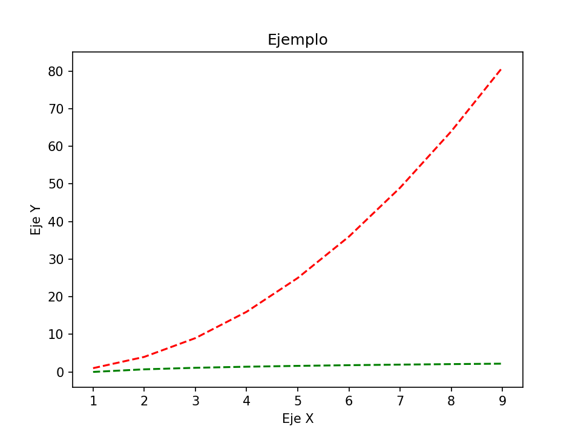

```python
# Indicamos al Notebook que queremos figuras interactivas (esto sólo es necesario hacerlo una vez)
%matplotlib notebook

import matplotlib.pyplot as plt  # Importamos la librería (esto sólo es necesario hacerlo una vez)
import math

# definimos algunas líneas de tendencia arbitrarias
vectorx = [x for x in range (1,10)]
vectorlogy = [ math.log(i) for i in vectorx ]
vectorpowy = [ math.pow(i, 2) for i in vectorx ]

fig = plt.figure()  # Creamos una figura (contenedor para elementos a dibujar)
ax = fig.add_subplot(111, projection='rectilinear')  # añadimos subplot-canvas a la figura (contiene los elementos del dibujo)

# añadimos los plots
ax.plot(vectorx, vectorlogy, '--', color="green")
ax.plot(vectorx, vectorpowy, '--', color="red")

ax.set_title("Ejemplo")  # Ponemos un título
ax.set_xlabel("Eje X")  # Nombramos los ejes
ax.set_ylabel("Eje Y")

plt.show()  # Mostramos a figura por pantalla, que se corresponde con la fig creada arriba
```

# El Problema del Viajante de Comercio (VC) con Búsqueda Tabú

De nuevo, trataremos de resolver el problema del Viajante de Comercio, pero ahora con el algoritmo de Búsqueda Tabú.

El objetivo de esta práctica es modelar e implementar un agente inteligente que sea capaz de resolver el problema del VC mediante la metaheurística (MH) de Busquedá Tabú (TS, del inglés Tabu Search). Para ello, realizarás una implementación del algoritmo básico visto en la clase expositiva y valorarás si la introducción de modificaciones en el diseño del algoritmo te permite mejorar la calidad de las soluciones alcanzadas.

## Definición del problema de Viajante de Comercio (VC)

El problema del viajante de comercio (VC) es el problema de la persona que quiere vender un producto, y que para ello quiere encontrar el viaje más corto posible a través de las ciudades de los clientes, haciendo una única visita a cada una, empezando y acabando el recorrido en su propia ciudad (recorrido circular desde la ciudad inicial). Típicamente, el problema parte de una representación mediante un grafo ponderado $G=(N, A)$, donde $N$ es el conjunto de $n=|N|$ nodos (ciudades), y siendo A el conjunto de arcos conectando los nodos. Cada arco $(i, j) ∈ A$ tiene asignado un peso $d_ij$ que representa la distancia entre las ciudades $i$ y $j$. El VC se reduce al problema de crear el circuito Hamiltoniano de longitud mínima sobre el grafo $G$. La solución a una instancia del problema del VC puede representarse como una permutación de los índices de las ciudades, donde lo importante es el orden de visita, que determinará el coste del viaje en términos de la distancia recorrida total. De este modo, el problema pertenece a la categoría de problemas NP, pues puede haber n permutaciones que se corresponden al espacio de búsqueda posible. Esto hace que resolver instancias de problemas con muchas ciudades (n grande) haga el problema impracticable con estrategias de búsqueda no-informadas y éste pueda beneficiarse de ciertas metaheurísticas, pudiendo abordar de problemas con tallas más grande a la vez que se obtienen soluciones razonablemente buenas.

### Nociones previas

Para facilitar vuestra labor de implementación, os proporcionamos la clase `Localizaciones`, que permite cargar las localizaciones GPS que representan los vértices del grafo G de N ciudades, y permite calcular de manera transparente la distancia entre cualquier par de ciudades usando la [fórmula del semiverseno](https://es.wikipedia.org/wiki/F%C3%B3rmula_del_semiverseno), que sirve para calcular las distancias teniendo en cuenta la curvatura de la Tierra. Es importante tener en cuenta que en la fórmula del semiverseno las coordenadas se expresan en radianes.

En primer lugar importa el módulo Python que acompaña esta práctica, que trae alguna función de apoyo implementada así como la clase de carga de datos.

```python
from helpers_mod_sa import *
```

Inspecciona el código de carga de localizaciones mediante `psource(Localizaciones)`

```python
psource (Localizaciones)
```

```
class Localizaciones ():

    def __init__ (self, filename='./data/grafo8cidades.txt'):
        self.filename = filename
        file = open(filename, 'r')
        Lines = file.readlines()

        count = -1
        self.nciudades = 0
        self.tablaciudades = dict()
        for line in Lines:
            if count == -1:
                self.nciudades = int(line.strip().split()[0])
            else:
                tokens = line.strip().split()
                self.tablaciudades[count]=tuple((float(tokens[0]),float(tokens[1])))

            count+=1

        self.matriz = []
        for c1 in range(self.nciudades):
            a = [0]*self.nciudades
            self.matriz.append(a)
            for c2 in range(self.nciudades):
                self.matriz[c1][c2] = self.__distancia_semiverseno__(c1, c2)

    def __distancia_semiverseno__ (self, c1, c2):
        radioTierra = 6371
        lat1 = math.radians(self.tablaciudades[c1][0]);
        lon1 = math.radians(self.tablaciudades[c1][1]);
        lat2 = math.radians(self.tablaciudades[c2][0]);
        lon2 = math.radians(self.tablaciudades[c2][1]);

        sinChi = math.sin((lat2 - lat1) / 2);
        sinLambda = math.sin((lon2 - lon1) / 2);

        raiz = (sinChi * sinChi) + math.cos(lat1) * math.cos(lat2) * (sinLambda * sinLambda);

        return 2 * radioTierra * math.asin(math.sqrt(raiz));

    def distancia (self, c1, c2):
        return self.matriz [c1][c2]
```

Fíjate que por defecto se carga el fichero `./data/grafo8cidades.txt`, que contiene las coordenadas GPS de 8 ciudades gallegas, siendo Santiago de Compostela la primera de ellas. La primera línea de estos ficheros indica el número de ciudades n, mientras que cada una de las líneas sucesivas especifican las coordenadas de cada ciudad, especificadas como coordenadas GPS (latitud y longitud en grados).

Puedes cargar otro fichero haciendo uso del parámetro `filename` como se muestra a continuación. Si todo va bien, la primera distancia entre la ciudad 0 y 1 debe ser unos 55 km.

❗ Para esta práctica, **debéis utilizar** el fichero `./data/grafo100cidades.txt` que contiene las coordenadas de 100 concellos gallegos.

```python
g1=Localizaciones(filename='./data/grafo8cidades.txt')
print (g1.distancia(0,1))
g2=Localizaciones(filename='./data/grafos10_10/grafo_1.txt')
print (g2.distancia(0,1))
g3=Localizaciones(filename='./data/grafo100cidades.txt')
print(g3.distancia(0,1))
```

```
55.88273580792048
119.30959564041359
68.81748609463234
```

## P2.1: Implementación básica de Búsqueda Tabú (especificación obligatoria, 6pts)

En este apartado debes desarrollar una **versión básica del algoritmo de Búsqueda Tabú que resuelva el problema del viajante de comercio (TSP)** aplicado a los concellos de Galicia. La especificación del algoritmo será muy detallada, ya que el objetivo principal de esta primera parte es que dispongas de una implementación totalmente funcional y verificada que resuelva el problema correctamente. Igual que en la práctica anterior (P1), consideramos que el recorrido es circular (empieza y termina en el mismo concello) y que tienen que pasar por N=100 concellos de Galicia. Implementa el algoritmo básico de Búsqueda Tabú para resolver el problema del VC enunciado arriba. Para ello, revisa la descripción algorítmica de la MH vista en la clase expositiva.

Ten en cuenta las **siguientes consideraciones** de diseño para completar la implementación básica:

- **Representación de las soluciones:** representación de orden (permutaciones) **comenzando y finalizando en la ciudad 0**. Es decir, utilizamos una representación de orden formada por una secuencia de valores numéricos que representan cada uno de los concellos {0, 1, ..., 99}. Consideramos siempre como punto de partida y retorno el concello 0, por lo que efectivamente una solución *S* se representa como una permutación de los demás valores {1, ..., 99}.
- **Solución inicial:** generación **totalmente aleatoria** de una permutación válida como está explicado en los apartados previos.

❗ **NOTA: Es importante que la generación de la solución inicial se implemente en una función propia y que después, esta solución inicial se pase a la función que implementa el algoritmo de búsqueda tabú *per se*.**

- **Operador de generación de vecindario de una solución** (generación de la solución siguiente $S_{cand}$ a partir de la actual $S_{act}$): Se utilizará el **operador de intercambio** y se generarán *todos los posibles intercambios**. Es decir, con este operador, se explota el vecindario de forma completa, con lo que se genera el siguiente número de vecinos:

$$ \sum_{i=1}^{L-1}i = \frac{L(L-1)}{2} $$

donde *L* es la longitud de la solución y se ha tenido en cuenta que es lo mismo intercambiar los vecinos *i, j* que *j, i*.

❗ **NOTA: Es importante que la generación del vecindario de una solución se implemente en una función propia y que después, el vecino seleccionado, se pase a la función que implementa el algoritmo de búsqueda tabú *per se*.**

- **Función de coste:** suma de las distancias del camino según el orden del recorrido teniendo en cuenta que se parte de y se llega al concello 0. La distancia se calcula teniendo en cuenta los siguientes tres elementos:
  - Distancia desde el concello 0 al primer concello de la solución: 0 -> S[0]
  - Distancia recorrida en la solución: S[0] -> S[1] -> ... -> S[-1]
  - Distancia recorrida desde el concello final al concello 0: S[-1] ->0
- **Lista Tabú:** La lista tabú (LT) estará formada por los **movimientos de intercambio de índices** {i,j} que den lugar a las soluciones que forman la trayectoria de búsqueda. Tenéis que establecer **N=100** como parámetro de tenencia tabú, esto es, el tamaño de la lista tabú será de **N** elementos, de forma que un movimiento {i,j} saldrá de la lista tabú después de **N=100** operaciones y volverá a estar permitido.
- **Reinicialización:** En el caso de que transcurran **1000 iteraciones consecutivas** sin que mejore la solución óptima $S_{opt}$ alcanzada hasta el momento, se hará una reinicialización desde ella: $S_{opt}$. Se trata por tanto de una estrategia de reinicialización por **intensificación**. En el reinicio **no se restaura la lista tabú**, para dar opción a visitar vecinos no visitados anteriormente ya que determinados intercambios prohibidos al estar incluidos en la lista tabú. Es decir, cuando se hace un reinicio, se vuelve a la solución $S_{opt}$ y **se vacía la lista tabú.**
- **Criterio de parada:** Se finaliza la ejecución cuando se alcanzan **10.000 iteraciones** del algoritmo.

### Preguntas sobre la especificación básica obligatoria (se responde al final del notebook)

❓ **Pregunta 1**. Explica brevemente los detalles relevantes de tu código para entender tu implementación (p.ej., estructura de tu código, funciones, etc.)

❓ **Pregunta 2**. La parte experimental de la práctica consiste en realizar **10 ejecuciones diferentes** de la implementación realizada y reportar:

- **Media y desviación** estándar de la mejor solución obtenida.
- El **número de iteración** en el que se obtuvo la mejor solución (por lo que debéis mantener además de la solución óptima hasta el momento $S_{opt}$, la iteración en la que se obtiene).
- El **tiempo de ejecución** del algoritmo (en las nociones previas se explica cómo hacer esto).

## P2.2: Mejoras del algoritmo de Búsqueda Tabú (especificación opcional, 4pts)

En este apartado el objetivo es aplicar la resolución del problema que acabáis de programar a un nuevo conjunto de 120 localizaciones tomadas del archivo de [50.000 lugares históricos del Registro Nacional de los EE.UU](http://www.math.uwaterloo.ca/tsp/us/data.html), tal y como se describe en la web del [Traveller Salesman Problem (TSP)](http://www.math.uwaterloo.ca/tsp/) del [Department of Combinatorics and Optimization](https://uwaterloo.ca/combinatorics-and-optimization/) de la University of Waterloo CA [(Prof. William Cook)](http://www.math.uwaterloo.ca/~bico/). Para evitar problemas de tiempo excesivo de cómputo, reduciremos el problema a 120 localizaciones que se indican en el fichero **US120.txt**.

**NOTA:** Si alguno de vosotros quiere realizar pruebas con todos los lugares indicados, puede obtener el fichero de texto original en el [siguiente enlace](http://www.math.uwaterloo.ca/tsp/us/files/us50000_latlong.txt).

En esta sección el objetivo es realizar mejoras al algoritmo desarrollado previamente, de acuerdo a lo visto en las clases expositivas. Podrá modificarse cualquier parámetro u operador, como por ejemplo:

- **Generación de la solución inicial** (inicialización greedy, ...)
- **Gestión de la lista tabú** con la inclusión de algún criterio de aspiración (por ejemplo excluir de la lista una solución si mejora a la mejor solución hasta el momento)
- El **operador de generación de vecinos** (por ejemplo no considerar todos los pares de índices, cambiar el operador de generación, ...)
- Utilizar **otras estrategias de reinicialización** por intensificación (por ejemplo reiniciar desde una solución aleatoria de un conjunto de las N mejores soluciones hasta ahora, restaurar la lista tabú, ...).
- Cambiar la **estrategia de reinicialización para dar diversificación** con una estrategia de **memoria a largo plazo**. Como puede ser utilizar una matriz simétriza *frec* que almacene elnúmero de veces que cada par de ciudades han sido consecutivas en las soluciones aceptadas hasta el momento. Con esta matriz de frecuencias se podría realizar una inicialización voraz sobre una matriz de distancias modificada que incluya las frecuencias almacenadas en memoria y penalice los pares de ciudads con mayor frecuencia, incrementando ficticiamente su distancia:

$$ D(i,j)_{MOD} = D(i,j) + \mu (D_{MAX} - D_{min}) \frac{frec(i,j)}{frec_{MAX}} $$

- Utilizar un criterio de **oscilación estratégica** que alterne entre las estrategias de intensificación y diversificación**-

### Preguntas sobre la práctica optativa con las mejoras (se responde al final del notebook)

❓ **Pregunta 3**. ¿Qué intervenciones de mejora te ha llevado a mejores resultados? Explica brevemente las mejoras o intervenciones de mejora realizadas, cómo la has implementado, porqué las consideras buenas para el problema y presenta tus conclusiones acompañadas de los resultados obtenidos.

# Respuestas a las preguntas y evaluación

**Recordatorio:** No olvides escribir tu nombre y apellidos en la segunda celda de este documento. La respuestas a las preguntas deben venir acompañadas de las implementaciones necesarias para su respuesta.

## P2.1 Especificación obligatoria (6pt)

La implementación básica se evaluará mediante un cuestionario automático de evaluación. Es también necesaria **realizar la implementación del algoritmo** y **responder a las preguntas 1 y 2** respectivamente. El cuestionario de evaluación lo realizarás en la primera sesión de la próxima práctica, y se centrará en la resolución por tu parte de diversas cuestiones prácticas relacionadas con la implementación realizada, pudiendo ser necesaria la ejecución, adaptación y modificación de la misma.

Aclaración: Independientemente del cuestionario automático de evaluación, siempre considera que las preguntas planteadas en el notebook deben ser respondidas también. Esas preguntas generales están diseñadas para formarte, y te servián para razonar y reflexionar sobre el tema, así como también para fomentar una discusión constructiva con los docentes en caso de dudas.

### **Pregunta 1**

Explica brevemente los detalles relevantes de tu código para entender tu implementación (p.ej., estructura de tu código, funciones, etc.)

*Incluye todas las celdas que consideres oportunas para que sea legible y fácil de seguir.*

**NOTA:** ¿Cómo me aseguro de que mi implementación es correcta? Es importante que para poder comprobar la correcta implementación de tu solución, tu código tenga en cuenta los siguientes elementos: - Mantener en cada iteración la mejor solución encontrada hasta el momento y la iteración en la que se encontró - Que puedas imprimir los elementos que se encuentran en la lista tabú - Saber en qué iteraciones se llevaron a cabo los reinicios

**NOTA:** Para verificar tu implementación, debes utilizar el fichero de localizaciones de los 100 concellos gallegos (grafo100cidades.txt). Puedes utilizar como prueba para verificar que la implementaición es correcta inicialmente, el fichero de localizaciones de 8 ciudades gallegas (grafo8cidades.txt). La solución óptima resuelta con una búsqueda informada como A* se situa en torno a los 382km para el problema de prueba con 8 ciudades.

**AYUDA EXTRA**: Si quieres comprobar la implementación de tu práctica puedes probar a utilizar como solución inicial la solución siguiente (pasándosela directamente a la función que implementa el algoritmo de búsqueda tabú): **Solución inicial:** - [77, 9, 43, 73, 2, 53, 12, 83, 92, 33, 50, 63, 54, 59, 64, 74, 55, 14, 35, 5, 58, 87, 37, 7, 69, 79, 89, 21, 23, 80, 20, 56, 75, 68, 27, 95, 78, 25, 88, 51, 47, 91, 49, 60, 13, 36, 70, 42, 11, 22, 40, 72, 28, 97, 19, 71, 29, 90, 85, 76, 16, 24, 81, 84, 34, 8, 31, 38, 67, 45, 44, 32, 96, 10, 61, 94, 17, 18, 93, 30, 52, 66, 99, 26, 46, 39, 15, 86, 41, 4, 62, 1, 48, 82, 57, 98, 3, 65, 6] Como resultados, deberías obtener los siguientes: - **Mejor solución:** [59, 69, 75, 53, 44, 10, 87, 12, 73, 38, 94, 41, 51, 15, 9, 99, 46, 32, 17, 92, 64, 37, 55, 23, 65, 79, 20, 4, 62, 86, 11, 63, 72, 26, 14, 48, 35, 60, 83, 70, 98, 47, 43, 58, 85, 19, 40, 5, 96, 68, 45, 25, 50, 89, 74, 27, 33, 97, 7, 84, 21, 16, 67, 66, 88, 29, 95, 8, 81, 31, 30, 49, 93, 61, 1, 78, 34, 13, 2, 80, 56, 82, 6, 22, 36, 71, 18, 91, 52, 90, 54, 57, 39, 28, 76, 24, 42, 77, 3] - **Coste de la solución:** 1663.18 - **Iteración en la que se encuentra la mejor solución (empezando a contar en 1):** 4633 **Prueba adicional con el fichero de grafo50cidadesA.txt**: **Solución inicial:** - [25, 6, 43, 23, 13, 47, 4, 11, 46, 41, 15, 38, 21, 26, 14, 42, 49, 32, 33, 3, 12, 20, 8, 48, 39, 28, 37, 45, 36, 2, 17, 9, 31, 29, 7, 24, 1, 5, 18, 35, 44, 22, 16, 30, 34, 10, 40, 19, 27] Como resultados, deberías obtener los siguientes: - **Mejor solución:** [16, 21, 28, 23, 37, 39, 7, 2, 34, 13, 38, 27, 33, 6, 22, 20, 4, 32, 17, 46, 18, 36, 11, 26, 14, 9, 15, 41, 48, 25, 45, 35, 5, 40, 19, 47, 43, 12, 49, 1, 31, 30, 10, 44, 8, 29, 3, 42, 24] - **Coste de la solución:** 1032.76 - **Iteración en la que se encuentra la mejor solución (empezando a contar en 1):** 4280

## Código

```python
import matplotlib.pyplot as plt
#funcion de representacion de las soluciones
def representacion_soluciones(localizaciones,solucion):
    #utilizamos los datos que ya nos da localizaciones
    latitudes = [coord[0] for coord in localizaciones.tablaciudades.values()]
    longitudes = [coord[1] for coord in localizaciones.tablaciudades.values()]

    plt.scatter(longitudes, latitudes, c='blue')
   # Dibujamos las líneas entre las ciudades en el orden de la solución
    for i in range(len(solucion) - 1):
        ciudad1 = solucion[i]
        ciudad2 = solucion[i + 1]
        latitudes = [localizaciones.tablaciudades[ciudad1][0], localizaciones.tablaciudades[ciudad2][0]]
        longitudes = [localizaciones.tablaciudades[ciudad1][1], localizaciones.tablaciudades[ciudad2][1]]
        plt.plot(longitudes, latitudes, c='red', linewidth=1)

    plt.show()
```

```python
#solucion inicial igual que en temple simulado
def genera_solucion_inicial(locaciones):
    sol = [x for x in range(1,locaciones.nciudades)]
    random.shuffle(sol)
    return [0]+sol+[0] #añadimos la primera ciudad que será el punto de partida y el punto final
```

```python
#funcion de coste igual que en temple simulado
def coste(locaciones,sol):
    suma = 0
    for i in range(0, len(sol)-1):
        suma+= locaciones.distancia(sol[i], sol[i+1])
    return suma
```

```python
def coste_vecino(g, sact, coste_act,movimiento,s_vecino):
    cambios= []
    for i in movimiento:
        cambios.append((i-1,i))
        cambios.append((i,i+1))

    coste = coste_act
    #restar al coste los movimientos que no son iguales
    for cambio in cambios:
        i,j = cambio
        #restar lo que costaba antes
        coste -= g.distancia(sact[i],sact[j])
        #sumar el nuevo coste
        coste += g.distancia(s_vecino[i],s_vecino[j])

    return coste
```

```python
# funcion de generacion de vecindario NO VAMOS A USAR ESTA, USAMOS LA VERSION 2
def genera_vecindario(g, sact, tabu):
    #hay que contar con todos los movimientos posibles
    veci = []
    for i in range(1,g.nciudades):
        for j in range(i+1,g.nciudades):#segundo num que cambiaremos
            movimiento = (i,j)
            #si el movimiento esta en la lista tabu no se hace
            if movimiento in tabu:
                continue
            veci.append(movimiento)#este movimiento esta permitido
    vecinos = {}
    #si hacemos un diccionario podemos poner como clave el movimiento
    for movimiento in veci:
        scand = sact.copy()
        i,j = movimiento
        scand[i], scand[j] = sact[j], sact[i]
        vecinos[movimiento] = scand
    return vecinos

#GENERACION DEL VECINDARIO
def generar_vecindario_2(g, sact, tabu):
    #hay que contar con todos los movimientos posibles
    veci = []
    for i in range(1, g.nciudades):
        for j in range(i + 1, g.nciudades):  # segundo num que cambiaremos
            movimiento = (i, j)
            # si el movimiento está en la lista tabu, no se hace
            if movimiento in tabu:
                continue
            veci.append(movimiento)  # este movimiento está permitido
    vecinos = []
    cost = coste(g, sact)
    # si hacemos un diccionario, podemos poner como clave el movimiento
    for movimiento in veci:
        scand = sact.copy()
        i, j = movimiento
        scand[i], scand[j] = sact[j], sact[i]

        vecinos.append((scand, movimiento, coste_vecino(g, sact, cost, movimiento, scand)))
    return vecinos
```

```python
import random
LIMITE = 10000
N =100
def busqueda_tabu(g, condicion_parada= LIMITE):
    solucion_inicial =genera_solucion_inicial(g) #generamos la solucion inicial
    #solucion_inicial = inicio
    tabu = []#lista tabu vacia

    iteracion=0 #para guardar la iteracion de la solucion
    reiniciar=0 #contador de la reinicializacion
    solucion_actual= solucion_inicial
    coste_optimo = float("inf")#lo mas grande para que pille a la primera el coste
    solucion_optima = solucion_inicial

    i=0
    while(i!=condicion_parada):
        #generamos vecindario. Devuelve (solucion, movimiento, coste)
        vecinos = generar_vecindario_2(g,solucion_actual,tabu)

        coste_actual= float("inf")
        for vecino in vecinos:
            if vecino[2]<coste_actual:#si el vecino es mejor que el actual cambiamos toda la informacion a ese
                solucion_actual = list(vecino[0])
                movimiento = vecino[1]
                coste_actual = vecino[2]


        #si tras coger el mejor vecino este es mejor que la solucion optima hasta el momento
        if(coste_actual<coste_optimo):
            solucion_optima = solucion_actual
            movimiento= movimiento
            coste_optimo=coste_actual
            iteracion=i #guardamos la iteracion en la que se ha encontrado la solucion
            reiniciar=0 #ha mejorado asi q a 0 la reinicializacion
        else:
            reiniciar+=1 # si no mejora se suma al contador
            if(reiniciar==1000): #si se llega a 1000 se reinicia
                tabu=[]#lista vacia
                solucion_actual=solucion_optima
                reiniciar=0#reiniciamos

        if(len(tabu)==N):#si se llega al maximo de la lista
            tabu.pop(0) # se echa
        tabu.append(movimiento)

        i=i+1#sumar una iteracion al while

    return (coste_optimo, iteracion+1 )
```

```python
inicio3= [0,77, 9, 43, 73, 2, 53, 12, 83, 92, 33, 50, 63, 54, 59, 64, 74, 55, 14, 35, 5, 58, 87, 37, 7, 69, 79, 89, 21, 23, 80, 20, 56, 75, 68, 27, 95, 78, 25, 88, 51, 47, 91, 49, 60, 13, 36, 70, 42, 11, 22, 40, 72, 28, 97, 19, 71, 29, 90, 85, 76, 16, 24, 81, 84, 34, 8, 31, 38, 67, 45, 44, 32, 96, 10, 61, 94, 17, 18, 93, 30, 52, 66, 99, 26, 46, 39, 15, 86, 41, 4, 62, 1, 48, 82, 57, 98, 3, 65, 6,0]
g3=Localizaciones(filename='./data/grafo100cidades.txt')
sol3, iteracion3 = busqueda_tabu(g3, inicio3)
print(sol3, iteracion3)
```

[output not shown]

```python
inicio4 = [0,25, 6, 43, 23, 13, 47, 4, 11, 46, 41, 15, 38, 21, 26, 14, 42, 49, 32, 33, 3, 12, 20, 8, 48, 39, 28, 37, 45, 36, 2, 17, 9, 31, 29, 7, 24, 1, 5, 18, 35, 44, 22, 16, 30, 34, 10, 40, 19, 27,0]

g4=Localizaciones(filename='./data/grafo50cidadesA.txt')
sol4, iteracion4 = busqueda_tabu(g4,inicio4)
print(sol4, iteracion4)
```

[output not shown]

```python
g5=Localizaciones(filename='./data/US120.txt')
sol5, iteracion5 = busqueda_tabu(g5)
print(sol5, iteracion5)
```

```
27847.156303575128 7885
```

```python
estudio(g5,cantidad=5)
```

```
0
1
2
3
4
MEDIA COSTE: 30906.774585
DESVIACION TIPICA COSTE: 2115.538954
MEDIA TIEMPO: 622.089706
DESVIACIÓN TIPICA TIEMPO: 26.177876
ITERACION SOLUCION OPTIMA: 3026
```

[output not shown]

### **Pregunta 2**

La parte experimental de la práctica consiste en realizar **10 ejecuciones diferentes** de la implementación realizada y reportar:

- **Media y desviación** estándar de las soluciones obtenidas.
- El **número de iteración** en el que se obtuvo la mejor solución (por lo que debéis mantener además de la solución óptima hasta el momento $S_{opt}$, la iteración en la que se obtiene).
- El **tiempo de ejecución** del algoritmo (en las nociones previas se explica cómo hacer esto).

*Incluye todas las celdas que consideres oportunas para que sea legible y fácil de seguir.*

```python
import time
# escribe aquí el código que utilizas para realizar la parte experimental de la práctica
def estudio(g, cantidad = 10):
    resultados = []
    iteracion = -1
    for i in range(0,cantidad):
        print(i)
        inicio = time.time()
        coste, iteracion = busqueda_tabu_reinicia(g)
        fin = time.time()
        tiempo =fin-inicio

        resultados.append((iteracion,coste,tiempo))

    mejor = float("inf")
    for result in resultados:
        if result[1]<mejor:
            mejor = result[1]
            iteracion = result[0]
    cost_values = [result[1] for result in resultados]
    time_values = [result[2] for result in resultados]

    mean_cost = statistics.mean(cost_values)
    stdev_cost = statistics.stdev(cost_values)
    mean_time = statistics.mean(time_values)
    stdev_time = statistics.stdev(time_values)

    print("MEDIA COSTE: %f" % mean_cost)
    print("DESVIACION TIPICA COSTE: %f" % stdev_cost)
    print("MEDIA TIEMPO: %f" % mean_time)
    print("DESVIACIÓN TIPICA TIEMPO: %f" % stdev_time)
    print("ITERACION SOLUCION OPTIMA: %d" % iteracion)
    #return resultados
```

❗ **NOTA: sé conservador en tu estrategia para verificar tu implementación**, especialmente cuando empleas ficheros de datos grandes como el del problema de las 100 ciudades. Si dejas ejecutando tu algoritmo por un número elevado de iteraciones, puede resultarte útil medir el tiempo que tarda para tomar decisiones sobre donde establecer el límite.

## P2.2 Implementación de las mejoras (4 pt)

### **Pregunta 3**

¿Qué intervenciones de mejora te ha llevado a mejores resultados? Prepara un informe en el que explices brevemente las mejoras o intervenciones de mejora realizadas, cómo las has implementado, y diseña un laboratorio para obtener resultados que te permitan explicar porqué las consideras buenas para el problema y soportar tus conclusiones acompañadas de los resultados obtenidos. (MAX. aprox. 1200 palabras)

Aclaraciones: La evaluación de esta parte se llevará a cabo en términos de la completitud y correctitud del laboratorio implementado, así como de la calidad del propio informe, que debe ser conciso y preciso, pudiendo acompañarse de gráficas y tablas que faciliten y fundamenten la explicación e argumentación. Es muy importante explicar de manera clara, precisa y fundamentada. Se valorará más positivamente las intervenciones de mejora que tengan mayor dificultad de implementación que las triviales. Se reservará hasta un punto que se asignará en términos de la calidad de la mejor solución obtenida entre el conjunto de las prácticas entregadas (es por ello que no debes olvidar marcar en tu informe muy claramente cuál ha sido tu mejor solución y con qué configuración/versión).

*Incluye todas las celdas que consideres oportunas para que sea legible y fácil de seguir*

```python
# escribe aqui el codigo de la implementacion optimizada del algoritmo de busqueda tabu
# debe seguir la misma estructuración en funciones que la implementación obligatoria

#implementacion de la solucion inicial greedy
def genera_solucion_greedy(g):
    sol = [0] #empezamos poniendo el inicio
    for i in range(1, g.nciudades): #recorremos todas las ciudades
        punto, mejor_coste = None, None
        for i in range(1, g.nciudades):
            if i in sol: #si ya hemos pasado por esa ciudad no comprobamos
                continue
            coste = g.distancia(sol[len(sol) - 1], i) # calculamos el coste de ir a esa ciudad
            if not punto or coste < mejor_coste:
                punto, mejor_coste = i, coste # si es mejor coste que el guardado lo actualizamos
        sol.append(punto) #añadimos a la solución la mejor ciudad, la que menos distancia tiene con la actual
    return sol + [0]
```

```python
import random
LIMITE = 10000
N =100
def busqueda_tabu_greedy(grafo, condicion_parada= LIMITE):
    solucion_inicial =genera_solucion_greedy(grafo)
    #solucion_inical = inicio
    lista_tabu = []
    i=0
    iteracion=0
    contador=0
    solucion_actual= solucion_inicial
    coste_optimo = float("inf")
    solucion_optima = solucion_inicial
    while(i!=condicion_parada):
        vecinos = generar_vecindario_2(grafo,solucion_actual,lista_tabu)

        coste_actual= float("inf")
        for vecino in vecinos:
            if vecino[2]<coste_actual:
                solucion_actual = list(vecino[0])
                movimiento = vecino[1]
                coste_actual = vecino[2]


        if(coste_actual<coste_optimo):
            solucion_optima = solucion_actual
            movimiento= movimiento
            coste_optimo=coste_actual
            iteracion=i
            contador=0
        else:
            contador=contador+1
            if(contador==1000):
                lista_tabu=[]
                solucion_actual=solucion_optima
                contador=0



        if(len(lista_tabu)==N):
            lista_tabu.pop(0)
        lista_tabu.append(movimiento)

        i=i+1

    return (coste_optimo, iteracion+1 )
```

```python
g5=Localizaciones(filename='./data/US120.txt')
sol5, iteracion5 = busqueda_tabu_greedy(g5)
print(sol5, iteracion5)
```

```
25619.983016850816 2388
```

```python
#probamos diversificacion

import random
LIMITE = 10000
N =100
#matriz de frecuencias donde almacenar el numero de veces que se visita un par de ciudades.

def busqueda_tabu_diversificacion(g, condicion_parada= LIMITE):
    solucion_inicial =genera_solucion_inicial(g)
    #solucion_inicial = inicio
    i=0
    iteracion=0
    contador=0
    solucion_actual= solucion_inicial
    coste_optimo = float("inf")
    solucion_optima = solucion_inicial

    #matriz distancias
    d_max, d_min = None, None
    for i in range(0, g.nciudades):
        for j in range(i+1, g.nciudades):
            if d_max is None or d_max < g.distancia(i, j):
                d_max = g.distancia(i, j)
            if d_min is None or d_min > g.distancia(i, j):
                d_min = g.distancia(i, j)
    d_diff = d_max - d_min

    tabu = []
    frec, max_frec = [[0] * g.nciudades] * g.nciudades, 0



    while(i!=condicion_parada):
        vecinos = generar_vecindario_2(g,solucion_actual,tabu)
        coste_actual= float("inf")
        mejor_mov, solucion_actual =None, None
        for vecino in vecinos:
            j,k = vecino[1]
            extra = 0 if max_frec == 0 else (d_diff *(frec[j][k] / max_frec))
            #el extra es lo que se añade al vecino
            if (vecino[2]+extra) <coste_actual:
                solucion_actual = list(vecino[0])
                mejor_mov = vecino[1]
                coste_actual = (vecino[2] + extra)

        # El movimiento se almacena en la tabla de frecuencias
        j, k = mejor_mov
        frec[j][k] += 1
        if frec[j][k] > max_frec:
            max_frec = frec[j][k]


        if(coste_actual<coste_optimo):
            solucion_optima = solucion_actual
            mejor_mov= mejor_mov
            coste_optimo=coste_actual
            iteracion=i
            contador=0
        else:
            contador=contador+1
            if(contador==1000):
                tabu=[]
                solucion_actual=solucion_optima
                contador=0



        if(len(tabu)==N):
            tabu.pop(0)
        tabu.append(mejor_mov)

        i=i+1

    return (coste_optimo, iteracion+1 )
```

```python
#NO FUNCIONA

g5=Localizaciones(filename='./data/US120.txt')
inicio= time.time()
sol5, iteracion5 = busqueda_tabu_diversificacion(g5)
fin = time.time()
print(sol5, iteracion5)
print(fin-inicio)
```

```
32336.313810696134 9030
612.6417019367218
```

```python
import random
LIMITE = 10000
N =100
def busqueda_tabu_gestion(g, condicion_parada= LIMITE):
    solucion_inicial =genera_solucion_inicial(g)
    #solucion_inicial = inicio
    lista_tabu = []
    i=0
    iteracion=0
    contador=0
    solucion_actual= solucion_inicial
    coste_optimo = float("inf")
    solucion_optima = solucion_inicial
    while(i!=condicion_parada):
        vecinos = generar_vecindario_2(g,solucion_actual,lista_tabu)

        coste_actual= float("inf")
        for vecino in vecinos:
            if vecino[2]<coste_actual:
                solucion_actual = list(vecino[0])
                movimiento = vecino[1]
                coste_actual = vecino[2]


        if(coste_actual<coste_optimo):
            solucion_optima = solucion_actual
            movimiento= movimiento
            coste_optimo=coste_actual
            iteracion=i
            contador=0
            iteracion_mejora = 0
        else:
            contador=contador+1
            iteracion_mejora = 1
            if(contador==1000):
                lista_tabu=[]
                solucion_actual=solucion_optima
                contador=0



        if(len(lista_tabu)==N):
            lista_tabu.pop(0)
        if iteracion_mejora != 0:
            lista_tabu.append(movimiento)

        i=i+1

    return (coste_optimo, iteracion+1 )
```

```python
import time
g5=Localizaciones(filename='./data/US120.txt')
inicio= time.time()
sol5, iteracion5 = busqueda_tabu_gestion(g5)
fin = time.time()
print(sol5, iteracion5)
print(fin-inicio)
```

```
32656.591752389988 6955
609.7963035106659
```

```python
#Reinicialización aleatoria desde una solución de las N mejores soluciones hasta ahora:
import random

LIMITE = 10000
N = 100

def busqueda_tabu_reinicia(g, condicion_parada=LIMITE):

    def reinicializacion_aleatoria(solucion_optima, n_mejores, tabu):
        # Selecciona una solución aleatoria de las N mejores que no esté en la lista tabú
        candidatos = [sol for sol in n_mejores if sol not in tabu]
        if candidatos:
            nueva_solucion = random.choice(candidatos)
            return nueva_solucion
        else:
            # Si no hay candidatos disponibles, simplemente genera una solución aleatoria
            nueva_solucion = genera_solucion_inicial(g)
            return nueva_solucion


    solucion_inicial = genera_solucion_inicial(g)
    tabu = []
    iteracion = 0
    reiniciar = 0
    solucion_actual = solucion_inicial
    coste_optimo = float("inf")
    solucion_optima = solucion_inicial

    n_mejores = [solucion_optima]

    i = 0
    while i != condicion_parada:
        vecinos = generar_vecindario_2(g, solucion_actual, tabu)

        coste_actual = float("inf")
        for vecino in vecinos:
            if vecino[2] < coste_actual:
                solucion_actual = list(vecino[0])
                movimiento = vecino[1]
                coste_actual = vecino[2]

        if coste_actual < coste_optimo:
            solucion_optima = solucion_actual
            movimiento = movimiento
            coste_optimo = coste_actual
            iteracion = i
            reiniciar = 0
        else:
            reiniciar += 1
            if reiniciar == 1000:
                tabu = []
                solucion_actual = reinicializacion_aleatoria(solucion_optima, n_mejores, tabu)
                reiniciar = 0
                n_mejores = [solucion_optima]

        if len(tabu) == N:
            tabu.pop(0)
        tabu.append(movimiento)

        # Actualizar la lista de las N mejores soluciones
        if len(n_mejores) < N:
            n_mejores.append(solucion_actual)
        else:
            n_mejores.append(solucion_actual)
            n_mejores = sorted(n_mejores, key=lambda x: coste(g, x))[:N]

        i += 1

    return coste_optimo, iteracion + 1
```

```python
g5=Localizaciones(filename='./data/US120.txt')
estudio(g5, cantidad=3)
```

```
0
1
2
MEDIA COSTE: 32182.366240
DESVIACION TIPICA COSTE: 1003.518372
MEDIA TIEMPO: 635.297937
DESVIACIÓN TIPICA TIEMPO: 33.974103
ITERACION SOLUCION OPTIMA: 8947
```

### **Pregunta 1**

Explica brevemente los detalles relevantes de tu código para entender tu implementación (p.ej., estructura de tu código, funciones, etc.)

El código se estructura en distintas funciones que ayudan a que la implementación sea modular. Estas funciones son:

- genera_solucion_inicial : inicializa la solucion inicial de forma aleatoria añadiendo la ciudad de partida al inicio y al final.
- coste: calcula el coste de una solucion en un grafo dados.
- coste_vecino: calcula el coste de una solucion en un grafo teniendo el coste de el vecino del que proviene. De esta forma el calculo de el coste de todos los vecinos es mucho más sencillo que si tuvieran que hacer el coste de cada uno. Teniendo el movimiento que ha cambiado se resta del coste las distancias a las ciudades cambiadas y se suman las nuevas distancias.
- generar_vecindario_2: segunda version de generar vecindario que implemento y la definitiva. Se calcula todos los vecinos de una solución de un grafo y se devuelve un array con cada uno de los vecinos( la solucion), el movimiento que se ha hecho para llegar a ese vecino y el coste del vecino.
- busqueda_tabu: función que implementa todas las funciones anteriores para calcular el problema de VC con busqueda tabu.

Se puede observar más detenidamente en el código anterior.

### **Pregunta 2**

La parte experimental de la práctica consiste en realizar **10 ejecuciones diferentes** de la implementación realizada y reportar:

- **Media y desviación** estándar de las soluciones obtenidas.
- El **número de iteración** en el que se obtuvo la mejor solución (por lo que debéis mantener además de la solución óptima hasta el momento $S_{opt}$, la iteración en la que se obtiene).
- El **tiempo de ejecución** del algoritmo (en las nociones previas se explica cómo hacer esto).

```python
estudio(g3)
```

```
0
1
2
3
4
5
6
7
8
9
MEDIA COSTE: 1668.889719
DESVIACION TIPICA COSTE: 88.896047
MEDIA TIEMPO: 397.863277
DESVIACIÓN TIPICA TIEMPO: 65.917861
ITERACION SOLUCION OPTIMA: 2917
```

Como se puede observar la media del coste de la solución de este grafo es de 1668,889719 . La solución óptima se obtuvo en la iteración 2917 y de media cada ejecución se realizó en 397.863277 segundo lo que son 6 minutos y 38 segundos. La ejecución completa tardó 66 minutos 19 segundos.

## **Pregunta 3**

¿Qué intervenciones de mejora te ha llevado a mejores resultados? Prepara un informe en el que explices brevemente las mejoras o intervenciones de mejora realizadas, cómo las has implementado, y diseña un laboratorio para obtener resultados que te permitan explicar porqué las consideras buenas para el problema y soportar tus conclusiones acompañadas de los resultados obtenidos. (MAX. aprox. 1200 palabras)

Para mejorar el rendimiento del algoritmo de Busqueda Tabu, hemos implementado distintas variantes. Todas ellas se probarán sobre el grafo de 120 ciudades estadounidenses, por ello primero veremos los resultados de la busqueda tabú sobre este grafo sin ninguna mejora.

### Inicialización greedy

La primera variante que implementamos es la estrategia de inicialización greedy. La estrategia greedy es un aestrategia voraz que se basa en seleccionar la mejor opción disponible a cada paso. Este método puede parecer muy sencillo, pero al usarlo en la inicialización de nuestra solución inicial puede proporcionar una base sólida sobre la que iniciar la búsqueda de soluciones ópotimas. De esta forma se puede mejorar significativamente la eficacio del algoritmo aunque probablemente el coste en tiempo de ejecución sea más alto.

En nuestro código, para añadir esta inicialización, cambiamos la función que genera la solución principal y creamos una nueva genera_solucion_greedy en la que se recorrera cada ciudad que todavía no se haya visitado, se calculará su distancia con la ciudad actual y finalmente se añadirá a la solución la ciudad que esté más cerca (menos distancia). Esta búsqued se repetirá hasta haber visitado todas las ciudades y devolver la solución inicial completa.

```python
#Greedy
import time
g5=Localizaciones(filename='./data/US120.txt')
inicio= time.time()
sol5, iteracion5 = busqueda_tabu_greedy(g5)
fin = time.time()
print(sol5, iteracion5)
print(fin-inicio)
```

```
25619.983016850816 2388
833.4432461261749
```

La variante de búsqueda Tabú ha logrado reducir el coste a 25 mil, en comparación con los 30 mil de la versión sin variante. Sin embargo, el tiempo de ejecución se ha extendido de 10 minutos y medio a aproximadamente 14 minutos. Esta diferencia se debe a la búsqueda exhaustiva de soluciones iniciales de alta calidad, en contraste con la generación aleatoria previa. Aunque la inversión adicional de tiempo ha mejorado el coste final y la eficacia general, es importante sopesar la relación entre el tiempo y el coste, considerando las restricciones y prioridades específicas del problema en cuestión antes de optar por esta variante en la búsqueda Tabú.

### Gestión de la lista tabú

La siguiente variante será la gestión de la lista tabú con la inclusión de un criterio de aspiración. Este criterio es la exclusión de una solución de la lista si esta solución mejora la solución óptima actual. Para implementar esta mejora solo hay que hacer unas pequeñas modificaciones en el código general de la búsqueda tabú. En el caso de que la solución sea mejor que la solución óptima, no meteremos ese movimiento en la lista tabú, si la solución es peor, si que lo hacemos.

A continuación vemos la ejecución de esta mejora:

```python
g5=Localizaciones(filename='./data/US120.txt')
estudio(g5, cantidad=3)
```

[output not shown]

### Reinicialización aleatoria

La última mejora que probaremos será la de reinicialización aleatoria, que es una estrategia de reinicialización por intensificación. En este caso, cuando la búsqueda tabú no logra mejorar durante un cierto número de iteraciones ( en nuestro caso 1000), se realiza una reinicialización aleatoria para diversificar la búsqueda.

Para implementar esto creamos una nueva función, que toma tres argumentos: la mejor solución encontrada hasta el momento, una lista que contiene las N mejores soluciones y la lista tabu que almacena los movimientos prohibidos. Primero se crea una lista de candidatos de las mejores soluciones que no esten en la lista tabu y luego si hay candidatos se selecciona una solución aleatoria entre ellos y se devuelve como solución. En caso de no haber candidatos disponibles(todas las mejores soluciones estan en tabu), creamos una solucion inicial aleatoria.

```python
import time
g5=Localizaciones(filename='./data/US120.txt')
inicio= time.time()
sol5, iteracion5 = busqueda_tabu_reinicia(g5)
fin = time.time()
print(sol5, iteracion5)
print(fin-inicio)
```

```
30331.416125513533 9882
606.5144455432892
```

De las tres mejoras implementadas, la única que ha generado una mejora significativa es la que utiliza la inicialización de tipo "greedy". Sin embargo, es importante tener en cuenta que antes de aplicar esta mejora, se debe evaluar el aumento en el tiempo de ejecución que conlleva en el problema que queramos solucionar.